# Final Combined

Bridget Gibbons

12/3/2018

Enrollment trends were modeled for both males and females using linear regression, with the model results and the raw data displayed in Figure X. Both models show that year significantly predicts enrollment for each gender (Male Enrollment = 9069x(year) - 17112153, Female Enrollment = 30,130x(year) - 5.896e+07).

In 1967, there were 365,337 more males than females enrolled in graduate school. However, over the period of 1967 to 2015, the rate at which females enrolled as graduates exceeded that of males by more than 3x. For each subsequent year, the number of female students could be expected to increase on average by 30,130, while the number of males could be expected to increase by only 9,069. Overall enrollment was also steadily increasing during this time period, and females became the gender majority between 1987 and 1988. By 2015, the number of female graduate students exceeded males by 497,360.

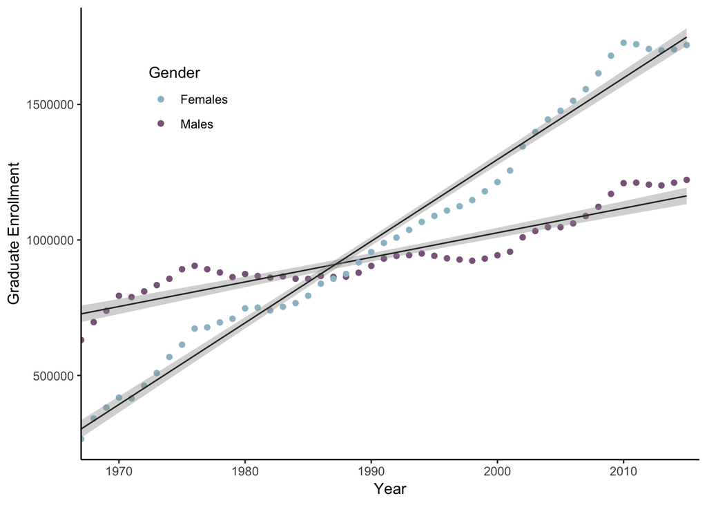

**Figure X. Relationship between graduate enrollment and year for males and females.** Gray region indicates the 95% confidence interval for the mean predicted value.Year significantly predicts total graduate enrollment for both males (b = 9069, t(47) = 16.6, p < 0.001) and females (b = 30,130, t(47) = 51.7, p < 0.001). The models explain a significant amount of variance in graduate enrollment for males (F(1,47) = 276, p < 0.001, R2 = 0.85) and females (F(1,47) = 2669, p < 0.001, R2 = 0.98). There is a strong correlation between year and enrollment for both males (Pearson’s R = 0.92) and females (Pearson’s R = 0.99).

**Table X: Female PhD Recipients by Field (1985, 2000, 2015)** Number of doctoral degrees awarded to women in the fields of Physical and Earth Sciences, Engineering, Education, and Humanities and Arts in the years 1985, 2000, and 2015.

| Year | Physical and Earth Sciences | Engineering | Education | Humanities and Arts |
| --- | --- | --- | --- | --- |
| 1985 | 569 | 198 | 3491 | 1392 |
| 2000 | 1022 | 838 | 4179 | 2672 |
| 2015 | 1988 | 2301 | 3502 | 2832 |

| Year | Physical and Earth Sciences | Engineering | Education | Humanities and Arts |
| --- | --- | --- | --- | --- |
| 1985 | 10.1% | 3.5% | 61.8% | 24.6% |
| 2000 | 11.7% | 9.6% | 48.0% | 30.7% |
| 2015 | 18.7% | 21.7% | 33.0% | 26.7% |

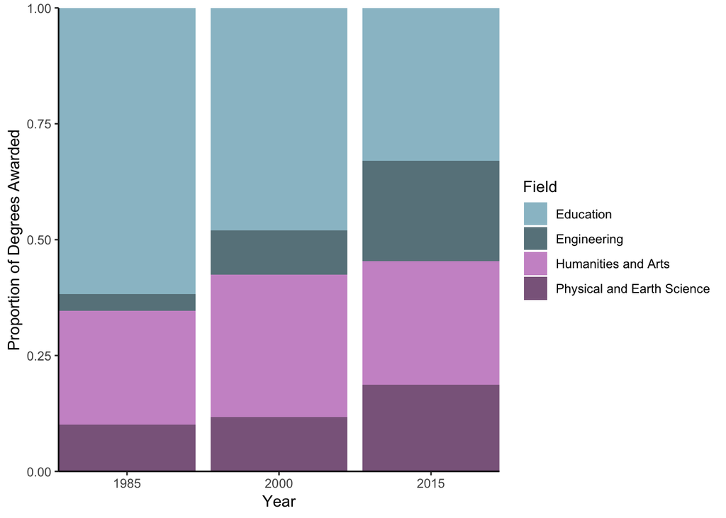

**Figure X: Female PhD Recipients by Field (1985, 2000, 2015)** Proportion of doctoral degrees awarded to women in the fields of Education, Engineering, Humanities and Arts, and Physical and Earth Science. See Table X for raw numbers of degrees awarded in each field every year, and Table X for exact proportions of degrees awarded to each field by year.

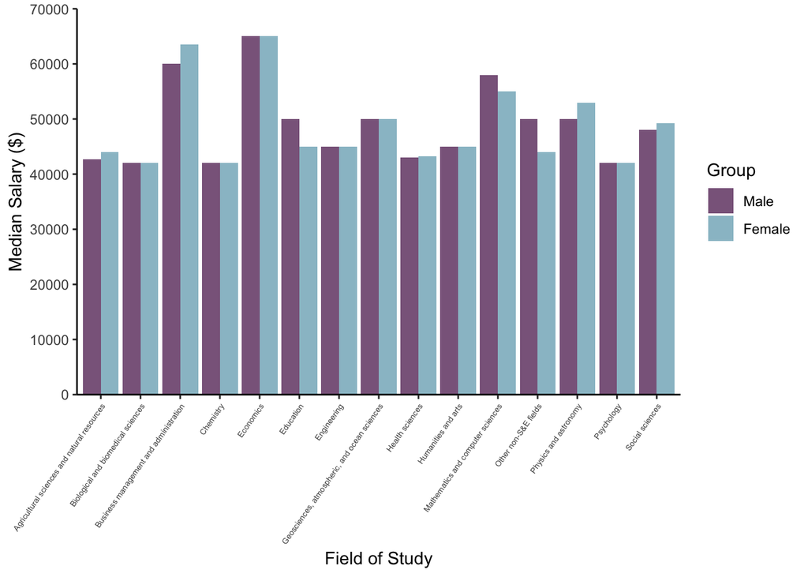

**Figure X. Median Salary for Males and Females in Postdoctoral Study by Field.** Distribution of median salary for males and females working in positions of post doctoratal study seperated by discipline in 2015. There is no significant difference between male and female median salaries within each field of study [W=19.5, p=0.89] (cliff’s delta = 0.04). Data used with permission from the National Science Foundation.

Male and female median salaries are equal in Biological and Biomedical Sciences, Chemistry, Economics, Engineering, Geoscience, Atmospheric and Ocean Sciences, Humanities and Arts, and Psychology. Among the remaining fields of study, male median salaries are higher than female median salaries in only Education, Mathematics and Computer Science, and Other non-S&E Fields. The greatest difference in median salaries between males and females is within the category of Other non-S&E Fields, where male median income is $6,000 greater than female median income.

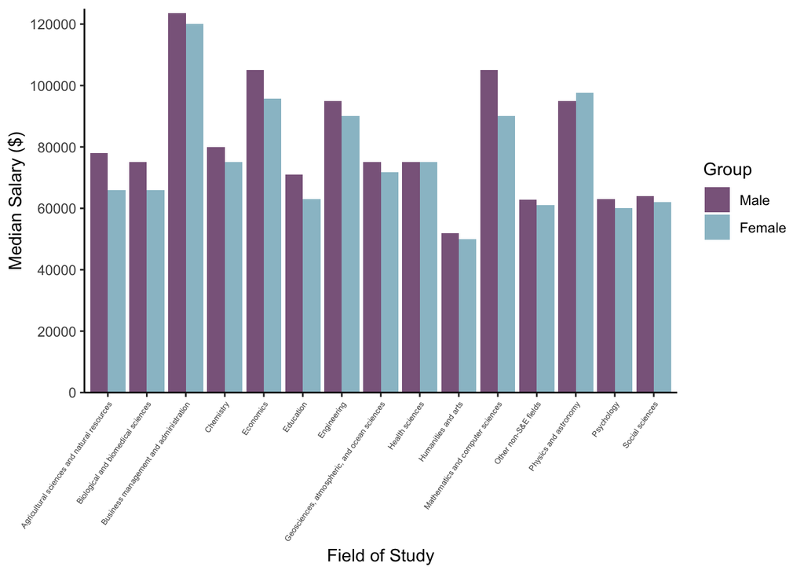

**Figure X. Median Salary for Males and Females in Postdoctoral Employment by Field.** Distribution of median salary for males and females working in post doctoratal employment seperated by discipline in 2015. There is a significant difference between male and female median salaries within each field of study [W=101, p=0.0026] (cliff’s delta = 0.213). Data used with permission from the National Science Foundation.

Within the population of doctoral recipients that are employed, male median salaries are equal to or greater than female median salaries in every field except Physics and Astronomy. The largest difference in median salaries between males and females is in Mathematics and Computer Sciences where men earn a median salary of $105,000 and women earn a median salary of $90,000, a difference of $15,000.

Multiple linear regression was used to model faculty salaries, and it was found that a model incorporating Rank, Discipline, and Sex explains a significant amount of variance in salary (Salary ($) = 13723(Associate Professor) + 47403(Professor) + 13709(Applied Discipline) + 4492(Male), F(4,392) = 79.18, p < 0.001, R^2 = 0.45). Three different levels of rank are incorporated into the model: assistant professor, associate professor, and professor; the reference level in the model is assistant professor. On average, associate professors can be expected to make 13,723 more than assistant professors if other factors are held constant, with professors making the most at 47,403 more than assistant professors. Both theoretical(A) and applied(B) disciplines were considered for the model, with the reference level set to theoretical disciplines. On average, it appears as though faculty members working within applied disciplines will make 13,709 more than their colleagues in theoretical disciplines. Lastly, the model looks at the sex of the faculty, with the reference level of the model set to female. Male faculty make 4,492 more than females on average, with all other factors held constant.

**Table X: Faculty Salary Regression Results**

|  | Salary |
| --- | --- |
| Assoc. Professor | 13,723.420*** |
|  | (3,959.014) |
| Professor | 47,403.320*** |
|  | (3,133.108) |
| Applied Discipline | 13,708.690*** |
|  | (2,295.437) |
| Male | 4,491.801 |
|  | (3,860.240) |
| Constant | 68,223.530*** |
|  | (4,477.200) |
| Observations | 397 |
| R<sup>2</sup> | 0.447 |
| Adjusted R<sup>2</sup> | 0.441 |
| Residual Std. Error | 22,640.990 (df = 392) |
| F Statistic | 79.180*** (df = 4; 392) |
| *Notes:* | ***Significant at the 1 percent level. |
|  | **Significant at the 5 percent level. |
|  | *Significant at the 10 percent level. |